# Highlighting the Need for Citizen Science and Sustainable Practices as Well as the Hope for Our Future on Oʻahu

Kyle-Jacob Laʻakea Gamiao

2024-10-20

[figure not shown]

[figure not shown]

## Introduction

Aloha mai kākou! O wau ʻo Kyle-Jacob Laʻakea Gamiao. No Puʻowaina mai au. I’ve chosen to do this project on the island of Oʻahu where I was born and raised. The specific aspects that this project focuses on are citizen science, sustainable practices, and the hope for our future. Below is a simple locator map of Oʻahu as well as the primary and secondary roadways

## Coding a Simple Locator Map of O’ahu

*Setting the Bounding Box*

```r
bb <- getbb("Oahu")
bb %>%
  opq()
```

```
## $bbox
## [1] "21.2548159,-158.2805762,21.712006,-157.6486277"
##
## $prefix
## [1] "[out:xml][timeout:25];\n(\n"
##
## $suffix
## [1] ");\n(._;>;);\nout body;"
##
## $features
## NULL
##
## $osm_types
## [1] "node"     "way"      "relation"
##
## attr(,"class")
## [1] "list"           "overpass_query"
## attr(,"nodes_only")
## [1] FALSE
```

*Creating the Environment*

```r
# Streets on Oʻahu
streets <- bb %>%
  opq() %>%
  add_osm_feature("highway", c("motorway", "primary", "secondary", "tertiary")) %>%
  osmdata_sf()

# Small streets on Oʻahu
small_streets <- bb %>%
  opq() %>%
  add_osm_feature(key = "highway", value = c("residential", "living_street", "unclassified", "service", "footway")) %>%
  osmdata_sf()

# Coastline on Oʻahu
coastline <- bb %>%
  opq() %>%
  add_osm_feature(key = "natural", value = "coastline") %>%
  osmdata_sf()
```

*Visualizing a Locator Map*

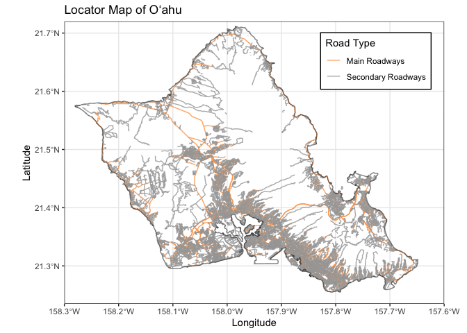

```r
oahu <- ggplot() +
  geom_sf(data = streets$osm_lines, inherit.aes = FALSE, aes(color = "Main Roadways"), size = 0.4, alpha = 0.8) +
  geom_sf(data = small_streets$osm_lines, inherit.aes = FALSE, aes(color = "Secondary Roadways"), size = 0.2, alpha = 0.8) +
  geom_sf(data = coastline$osm_lines, inherit.aes = FALSE, color = "black", size = 0.8, alpha = 0.5) +
  coord_sf(xlim = c(-158.3, -157.60), ylim = c(21.235, 21.72), expand = FALSE) +
  theme_bw() +
  labs(
    title = "Locator Map of Oʻahu",
    x = "Longitude",
    y = "Latitude",
    color = "Road Type"
  ) +
  scale_color_manual(values = c("Main Roadways" = "#ff9f4d", "Secondary Roadways" = "#a6a6a6")) +
  theme(legend.position = c(0.82, 0.86), legend.background = element_rect(fill = "white", color = "black"))
oahu
```

## Coding Map 1: ʻŌhiʻa Lehua on O’ahu through iNaturalist

The reason for this is to not only show how one of our culturally and environmentally important species is struggling, but how we need to do what we can for it and other organisms.

*ʻŌhiʻa Lehua Data from iNaturalist*

```r
inat_obs_df <- get_inat_obs(taxon_id = 60447, #taxon id from URL
                            place_id = 11, #place id from URL
                            quality = "research", #specifies research grade only
                            geo = TRUE, #Specifies that we want geocoordinates
                            maxresults = 100) #Limits results
save(inat_obs_df, file = "oahu_ohia_inat.Rdata")
```

*Loading Map*

```r
inat_obs_sf <-  inat_obs_df %>%
  select(longitude, latitude, datetime, common_name, scientific_name, image_url, user_login) %>%
  st_as_sf(coords=c("longitude", "latitude"), crs=4326)

dim(inat_obs_sf)
```

```
## [1] 100   6
```

```r
inat_obs_popup_sf <- inat_obs_sf %>%
  mutate(popup_html = paste0("<oahu><b>", common_name, "</b><br/>",
                             "<i>", scientific_name, "</i></oahu>",
                             "<oahu>Observed: ", datetime, "<br/>",
                             "User: ", user_login, "</oahu>",
                             "<oahu><img src='", image_url, "' style='width:100%;'/></oahu>")
  )
```

Below is an interactive map of Oʻahu that shows iNaturalistʻs recordings of ʻōhiʻa lehua. Hawaiʻi and Oʻahu in particular were very well known for the different varieties of ʻōhiʻa. Over time the number of trees and varieties have seen a significant decline due to invasive species, rapid ʻōhiʻa death, land development, and many more factors. Although this map does not show all species and all locations of ʻōhiʻa on Oʻahu but it does highlight the need for two things. The *first* is citizen scientists. There are many people trying to collect data, but due to various reasons such as funding, accessibility, etc. itʻs difficult to aggregate all of the data and make it usable and available to the general public. The *second* thing to be highlighted is the need to focus on and take care of the environment. It is our kuleana to protect what we can and give back where we can. It’s sad to see such drastic decline in our native species.

*Map 1: iNaturalist Observations of ʻŌhiʻa Lehua on O’ahu*

```r
inat_obs_popup_sf <- inat_obs_sf %>%
  mutate(popup_html = paste0("<oahu><b>", common_name, "</b><br/>",
                             "<i>", scientific_name, "</i></oahu>",
                             "<oahu>Observed: ", datetime, "<br/>",
                             "User: ", user_login, "</oahu>",
                             "<oahu><img src='", image_url, "' style='width:100%;'/></oahu>")
  )

htmltools::p("iNaturalist Observations of ʻŌhiʻa Lehua on the Island of Oahu",
             htmltools::br(),
             inat_obs_popup_sf$datetime %>%
               as.Date() %>%
               range(na.rm = TRUE) %>%
               paste(collapse = " to "),
             style = "font-weight:bold; font-size:110%;")
```

iNaturalist Observations of ʻŌhiʻa Lehua on the Island of Oahu  
2007-08-09 to 2024-10-20

```r
leaflet(inat_obs_sf) %>%
  setView(lng = -157.99, lat = 21.525, zoom = 10)%>%
  addTiles() %>%
  addCircleMarkers(data = inat_obs_popup_sf,
                   popup = ~popup_html,
                   radius = 5)
```

[interactive chart not shown]

This message isn’t here to show the world is all doom and gloom, it’s to show that we should further our efforts and take more actions to help our environment and the organisms within it. There are many ways to think and act more sustainable and so many possibilities to improve environmental resilience in areas that we love; it just takes a long time a lot of work and a lot of behavioral changes to achieve these things.

## Coding Map 2: Schools on O’ahu and Potential for Education

The best way to evoke change and action is to educate others on the impact we have on the environment as well as things we can do to change both the future of nature and humans.

*School Data Retrieval*

```r
#Retrieving data of schools on O'ahu
schools <- bb %>%
  opq() %>%
  add_osm_feature(key = "amenity", value = "school") %>%
  osmdata_sf()
```

We reused the original locator map from the beginning of this paper, but incorporated more information to it to showcase our hope for the future. Below is a new locator map focused on the amount of schools we have here on O’ahu using OpenStreetMap.

*Map 2: OpenStreetMap Observations of O’ahu with Emphasis on Schools*

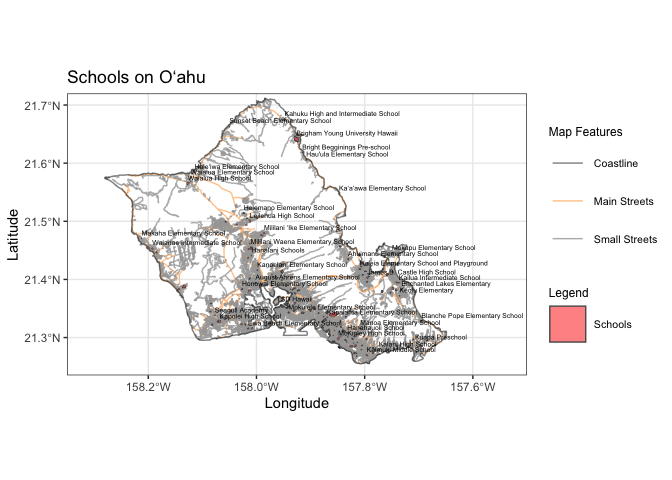

```r
ggplot() +
  geom_sf(data = streets$osm_lines, aes(color = "Main Streets"), inherit.aes = FALSE, size = .4, alpha = .8) +
  geom_sf(data = small_streets$osm_lines, aes(color = "Small Streets"), inherit.aes = FALSE, size = .2, alpha = .8) +
  geom_sf(data = coastline$osm_lines, aes(color = "Coastline"), inherit.aes = FALSE, size = .8, alpha = 0.5) +
  geom_sf(data = schools$osm_polygons, aes(fill = "Schools"), inherit.aes = FALSE, alpha = 0.5, size = 50) +
  coord_sf(xlim = c(-158.35, -157.50), ylim = c(21.235, 21.72), expand = FALSE) +
  geom_sf_text(data = schools$osm_polygons, aes(label = name),
               size = 1.8,
               hjust = 0,
               nudge_y = 0.01,
               check_overlap = TRUE) +
  theme_bw() +
  labs(
    title = "Schools on Oʻahu",
    x = "Longitude",
    y = "Latitude"
  ) +
  scale_color_manual(name = "Map Features",
                     values = c("Main Streets" = "#ffbe7f",
                                "Small Streets" = "#a6a6a6",
                                "Coastline" = "black")) +
  scale_fill_manual(name = "Legend",
                    values = c("Schools" = "red")) +
  theme(legend.position = "right",
        legend.text = element_text(size = 8),
        legend.title = element_text(size = 9),
        legend.key.size = unit(1, "cm")) +  # Adjust size here for legend keys
   guides(fill = guide_legend(override.aes = list(size = 0.4)))  # Set legend size for fill
```

One of our biggest sources of hope is displayed here on this map. The younger generations have the ability to change our future, so we should focus on ensuring they understand, not just the gravity of the situation but, the important role they have in changing the narrative. I was inspired by this approach during a recent event I went to by *Sustainable Coastlines* called “Sustainable Ghostlines”. One of the vendors who attended is a 16 year-old student named Genshu. His non-profit “Bottles 4 College” is an ingenious idea that takes recyclables and donations from the community and uses the resulting funds from recycling them to award scholarships to people in need. His company even donated money to the victims of Lahaina’s Wildfire last year (2023). He told me about his company, “for the community by the community.” That really resonated with me. To me it meant that community-based solutions for their own community has a higher chance for sustainability in the long-term. And I find that truly inspiring.

Remember to always look for hope, even in the face of seemingly insurmountable odds.

## Acknowledgements

I would like to give a special mahalo to Dr. Catherine Lee Brockway for her mentorship and help in developing my GIS skills. It means so much to me to have been given guidance and the tools to help my own community and the communities around me. Mahalo nui loa!